# Text Mining Ejercicio

Alejandro Valladares Vaquero

2019-08-31

# 1 Librerías necesarias

```r
library(wordcloud)
library(RColorBrewer)
library(tidyverse)
library(stringr)
library(gridExtra)
library(wordcloud)
library(lubridate)
library(tidytext)
library(tm)
library(reshape2)
```

# 2 Introducción

Este ejercicio se ha realizado utilizando el paquete tidytext, que es un paquete de Text Mining que sigue los principios de Tidy Data (H. Wickham).

Descargamos los datos de Kaggle, puesto que aún no hay una Kaggle oficial para R, el archivo se puede descargar del siguiente enlace https://www.kaggle.com/aaron7sun/stocknews/downloads/stocknews.zip Y leemos en una estructura tipo tibble.

## 2.1 Carga de los datos

O también podemos guardar el archivocomo un archivo serializado Rds, para que no haga falta abrir el zip cada vez. Abajo vemos un ejemplo de la distribución de los datos. Vemos que tenemos una primera columna con la fecha del día y las siguientes 25 columnas son los 25 titulares más destacados en el Reddit **r/worldnews** en el periodo entre Agosto de 2008 y Julio de 2017.

```r
news <- readRDS("data/news.rds")
head(news[,1:2],10)
```

```
## # A tibble: 10 x 2
##    Date       Top1
##    <date>     <chr>
##  1 2008-08-08 "b\"Georgia 'downs two Russian warplanes' as countries move ~
##  2 2008-08-11 b'Why wont America and Nato help us? If they wont help us no~
##  3 2008-08-12 b'Remember that adorable 9-year-old who sang at the opening ~
##  4 2008-08-13 b' U.S. refuses Israel weapons to attack Iran: report'
##  5 2008-08-14 b'All the experts admit that we should legalise drugs '
##  6 2008-08-15 "b\"Mom of missing gay man: Too bad he's not a 21-year-old c~
##  7 2008-08-18 b'In an Afghan prison, the majority of female prisoners are ~
##  8 2008-08-19 "b\"Man arrested and locked up for five hours after taking p~
##  9 2008-08-20 b'Two elderly Chinese women have been sentenced to a year of~
## 10 2008-08-21 "b\"British resident held in Guantanamo Bay wins legal battl~
```

## 2.2 Limpieza de los titulares

```r
news_text <- as_tibble(lapply(news[, 2:26], function(y)gsub("^b'", "", y)))
news_text <- as_tibble(lapply(news_text, function(y)gsub("^b\"", "", y)))
news_text <- as_tibble(lapply(news_text, function(y)gsub("[[:punct:]]", "", y)))
news_text <- as_tibble(lapply(news_text, function(y)tolower(y)))
news_text <- as_tibble(lapply(news_text, function(y)gsub("[ \t]{2,}", "", y)))
news_text <- as_tibble(lapply(news_text, function(y)gsub("^\\s+|\\s+$", "", y)))

news_text <- as_tibble(cbind(news[, 1],news_text))
head(news_text[,1:2],10)
```

```
## # A tibble: 10 x 2
##    Date       Top1
##    <date>     <chr>
##  1 2008-08-08 georgia downs two russian warplanes as countries move to bri~
##  2 2008-08-11 why wont america and nato help us if they wont help us now w~
##  3 2008-08-12 remember that adorable 9yearold who sang at the opening cere~
##  4 2008-08-13 us refuses israel weapons to attack iran report
##  5 2008-08-14 all the experts admit that we should legalise drugs
##  6 2008-08-15 mom of missing gay man too bad hes not a 21yearold cheerlead~
##  7 2008-08-18 in an afghan prison the majority of female prisoners are ser~
##  8 2008-08-19 man arrested and locked up for five hours after taking photo~
##  9 2008-08-20 two elderly chinese women have been sentenced to a year of r~
## 10 2008-08-21 british resident held in guantanamo bay wins legal battle to~
```

Una vez tenemos algo más ordenado y limpio el texto, se abre un gran abanico de posibilidades de trabajo como veremos a continuación.

# 3 Análisis del texto

Al tener las noticias separadas por orden de popularidad en r/worldnews, una posibilidad sería la de mantener este ranking e intentar analizar la temática o el sentimiento de las noticias más populares y ver como evolucionan con el tiempo. Por ejemplo sería muy útil ver si el factor que tienen sobre las noticias más populares grandes sucesos a nivel mundial (elecciones generales, crisis financieras, guerras, desastres naturales, grandes eventos deportivos, temáticas de primer orden mundial como el cambio climático, etc)

## 3.1 Análisis de sentimiento *estático*

Para esta entrega me voy a centrar en un **análisis estático**, es decir, voy a prescindir de las variable temporal y de la popularidad en el análisis. El objetivo es un simple análisis de contenido y sentimiento a lo largo de todos los años de titulares. Así podremos ver que es lo que más ha preocupado al mundo durante estos años (o lo que más ha preocupado a los usuarios de **r/worldnews**).

### 3.1.1 Ordenando el dataframe

Lo primero que vamos a hacer, es unir todos los titulares en una sóla columna.

```r
news_text_day <- news_text %>%
  unite("headlines", c(Top1:Top25), sep=" ")
head(news_text_day,10)
```

```
## # A tibble: 10 x 2
##    Date       headlines
##    <date>     <chr>
##  1 2008-08-08 georgia downs two russian warplanes as countries move to bri~
##  2 2008-08-11 why wont america and nato help us if they wont help us now w~
##  3 2008-08-12 remember that adorable 9yearold who sang at the opening cere~
##  4 2008-08-13 us refuses israel weapons to attack iran report when the pre~
##  5 2008-08-14 all the experts admit that we should legalise drugs war in s~
##  6 2008-08-15 mom of missing gay man too bad hes not a 21yearold cheerlead~
##  7 2008-08-18 in an afghan prison the majority of female prisoners are ser~
##  8 2008-08-19 man arrested and locked up for five hours after taking photo~
##  9 2008-08-20 two elderly chinese women have been sentenced to a year of r~
## 10 2008-08-21 british resident held in guantanamo bay wins legal battle to~
```

```r
tidy_news <- news_text_day %>%
  unnest_tokens(word, headlines)
head(tidy_news,10)
```

```
## # A tibble: 10 x 2
##    Date       word
##    <date>     <chr>
##  1 2008-08-08 georgia
##  2 2008-08-08 downs
##  3 2008-08-08 two
##  4 2008-08-08 russian
##  5 2008-08-08 warplanes
##  6 2008-08-08 as
##  7 2008-08-08 countries
##  8 2008-08-08 move
##  9 2008-08-08 to
## 10 2008-08-08 brink
```

### 3.1.2 Limpieza de stop-words

Una vez que tenemos el el texto en formato *tidytext*, podemos quitar las stopwrods directamente haciendo un anti-join.

```r
tidy_news <- tidy_news %>%
  anti_join(stop_words)

tidy_news %>%
  count(word, sort = TRUE)
```

```
## # A tibble: 47,229 x 2
##    word           n
##    <chr>      <int>
##  1 government  1903
##  2 police      1900
##  3 israel      1816
##  4 people      1801
##  5 china       1722
##  6 world       1608
##  7 war         1504
##  8 russia      1441
##  9 uk          1337
## 10 president   1324
## # ... with 47,219 more rows
```

### 3.1.3 Palabras más importantes

Una vez eliminadas las stop-words, vamos a pintar el histograma con las palabras más aparecidas a lo largo de los años.

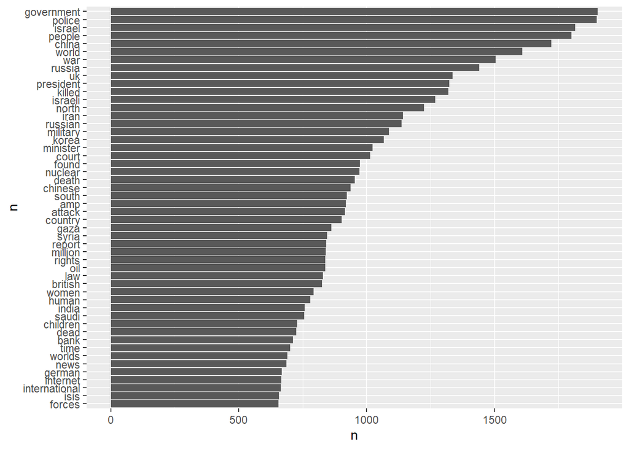

```r
tidy_news %>%
  count(word, sort = TRUE) %>%
  filter(n > 650) %>%
  mutate(word = reorder(word, n)) %>%
  ggplot(aes(word, n)) +
  geom_col() +
  xlab("n") +
  coord_flip() +
  scale_x_discrete()
```

### 3.1.4 Nube de palabras

[figure not shown]

```r
tidy_news %>%
  anti_join(stop_words) %>%
  count(word) %>%
  with(wordcloud(word, n, max.words = 150))
```

# 4 Análisis de sentimiento

Vamos a utilizar el lexicón *bing* que hay en el paquete *tidytext*.

```r
bing_word_counts <- tidy_news %>%
  inner_join(get_sentiments("bing")) %>%
  count(word, sentiment, sort = TRUE) %>%
  ungroup()
head(bing_word_counts, 10)
```

```
## # A tibble: 10 x 3
##    word     sentiment     n
##    <chr>    <chr>     <int>
##  1 killed   negative   1320
##  2 death    negative    954
##  3 attack   negative    916
##  4 dead     negative    725
##  5 protest  negative    588
##  6 top      positive    526
##  7 protests negative    504
##  8 attacks  negative    496
##  9 crisis   negative    490
## 10 prison   negative    448
```

## 4.1 Histograma con las palabras más utilizadas por sentimiento

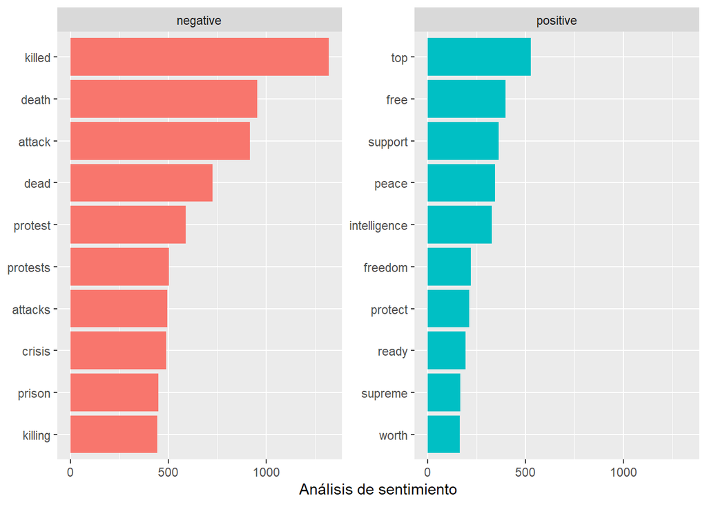

```r
bing_word_counts %>%
  group_by(sentiment) %>%
  top_n(10) %>%
  ungroup() %>%
  mutate(word = reorder(word, n)) %>%
  ggplot(aes(word, n, fill = sentiment)) +
  geom_col(show.legend = FALSE) +
  facet_wrap(~sentiment, scales = "free_y") +
  labs(y = "Análisis de sentimiento",
       x = NULL) +
  coord_flip()
```

Vemos claramente como los titulares tienden a ser más negativos que positivos.

## 4.2 Nube de palabras con *sentimiento*

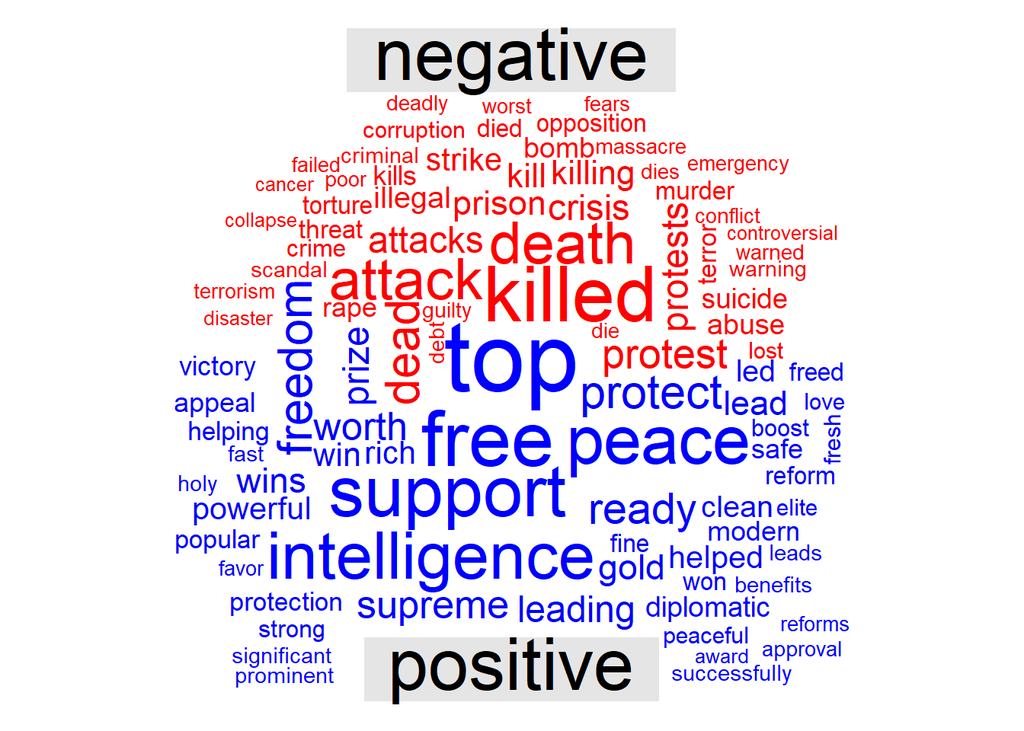

```r
tidy_news %>%
  inner_join(get_sentiments("bing")) %>%
  count(word, sentiment, sort = TRUE) %>%
  acast(word ~ sentiment, value.var = "n", fill = 0) %>%
  comparison.cloud(colors = c("red", "blue"),
                   max.words = 100)
```